# Transcriptomics data visualization

9 December 2019

## esetVis R package

## esetVis

esetVis is an R package to explore and visualize gene expression data provided in **ExpressionSet** format.

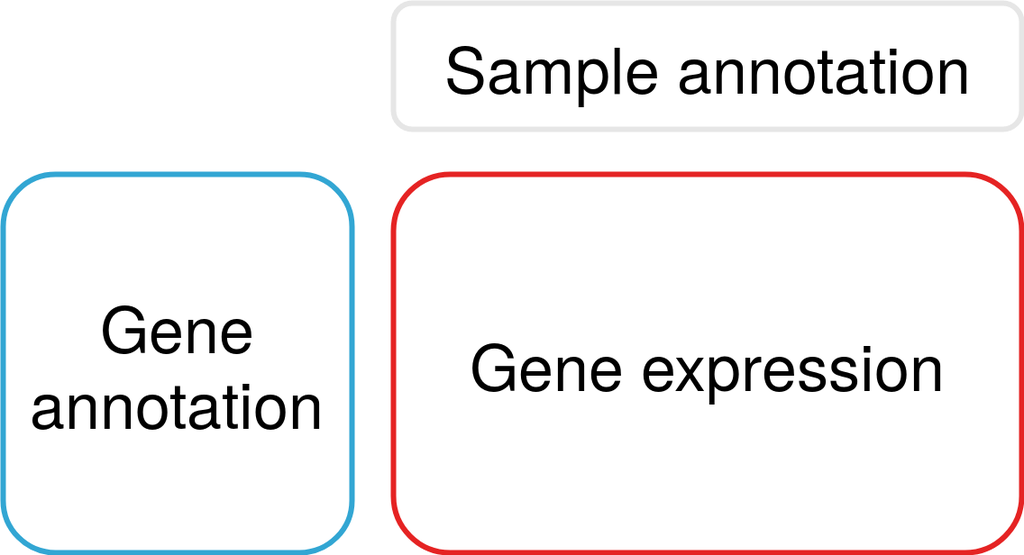

**Advantage:** Visualizations for any transcriptomics (e.g. microarray or RNAseq) or proteomics data

## esetVis

- visual exploratory data analysis
- create plots for specific features
- identify clusters of biological samples and genes

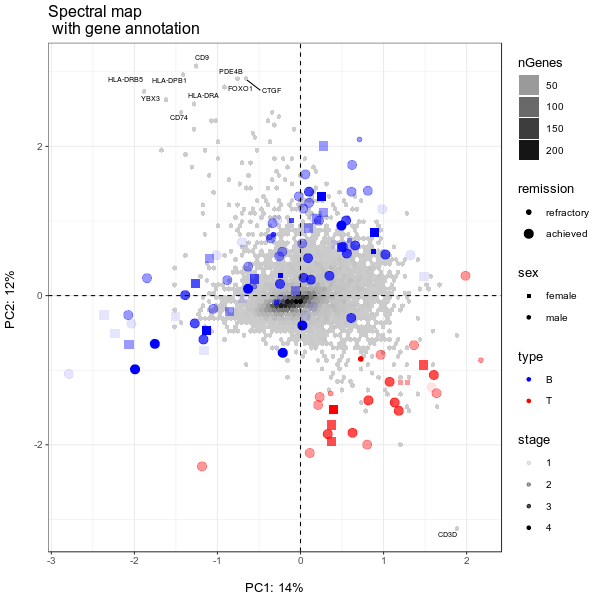

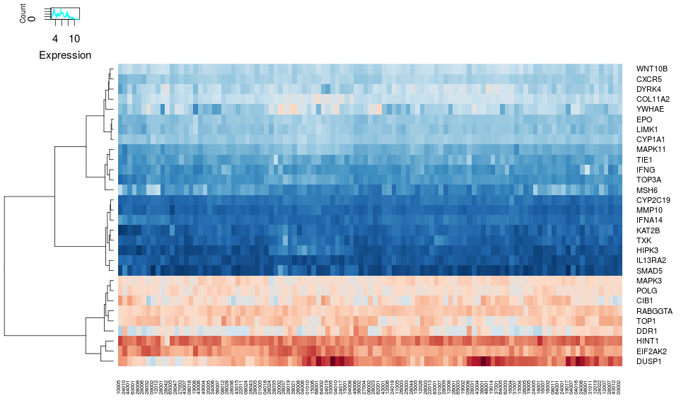

## esetVis

- investigate expression profile for a set of genes
- represent the correlation between genes

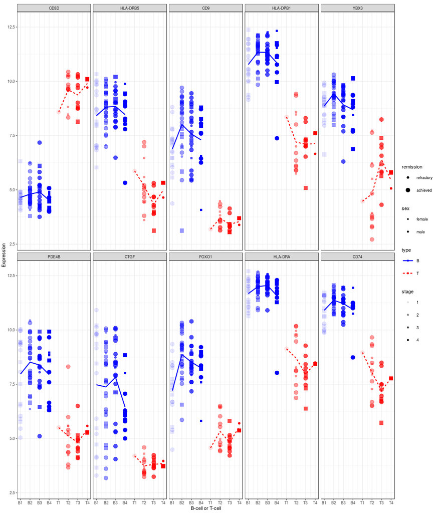

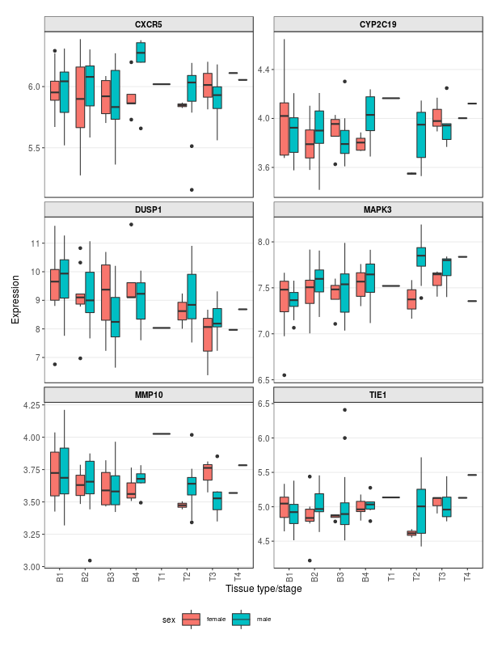

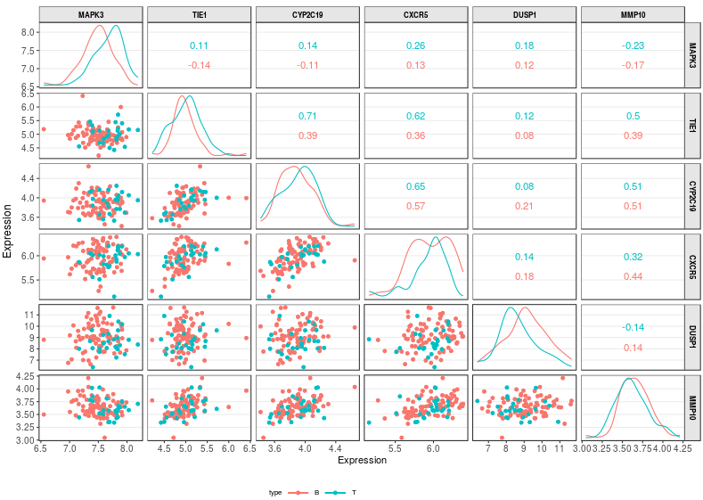

## daVis R package

## daVis

daVis is an R package to explore and visualize the output from differential expression analysis provided as a list of top tables.

## daVis

- visualize relation between logFC of multiple comparisons
- investigate overlap of significantly affected genes

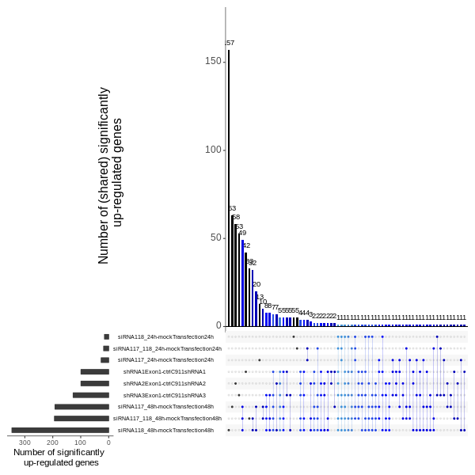

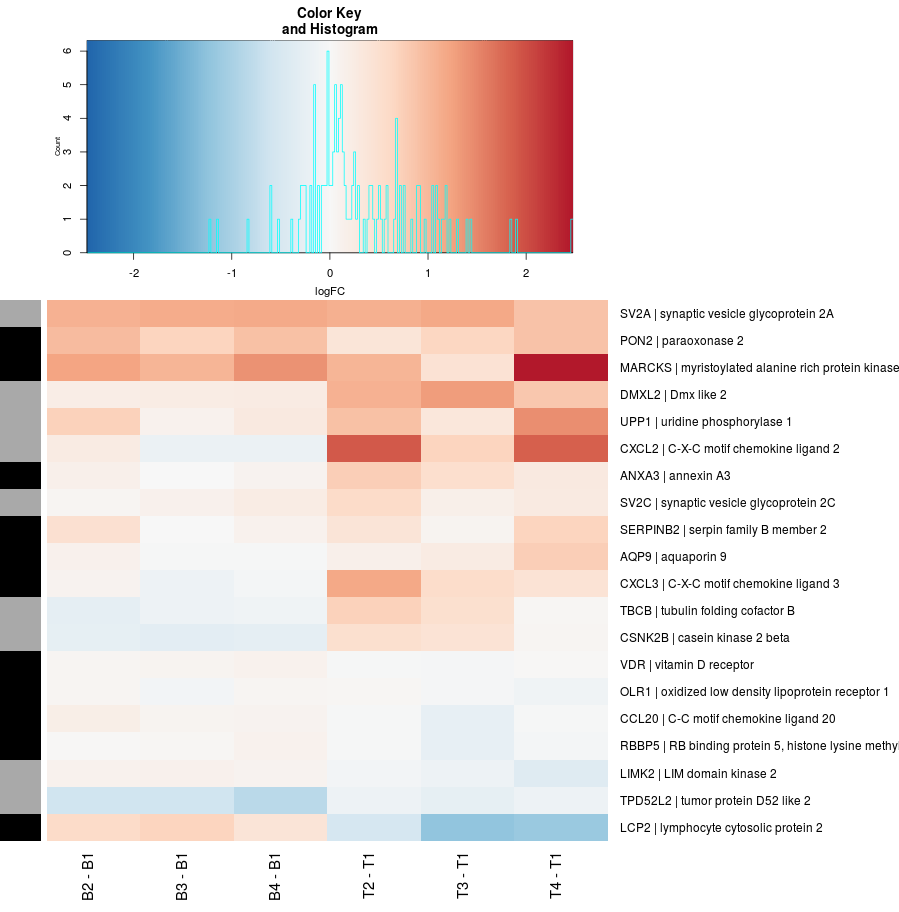

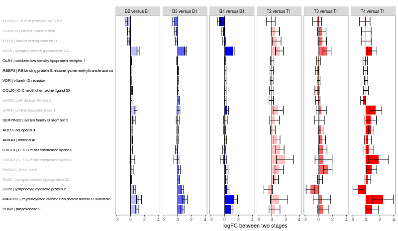

## daVis

- explore the relation between logFC and p-value

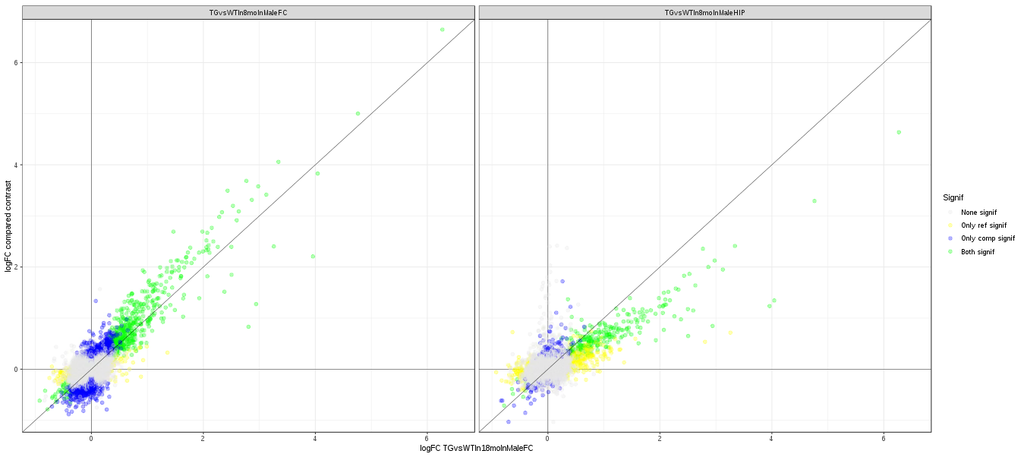

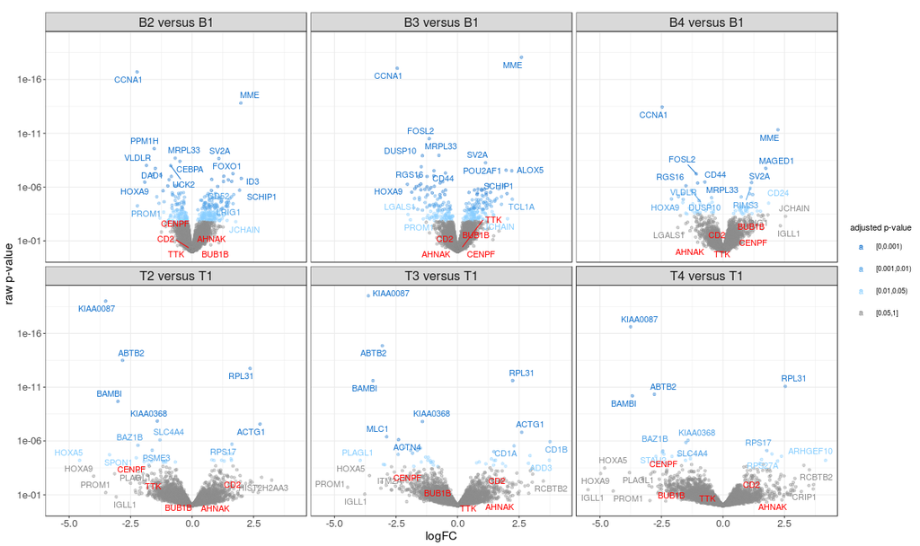

## transcriptomicsExplorer ShinyApp

## transcriptomicsExplorer

transcriptomicsExplorer is an interactive web application with a user-friendly interface to explore and visualize transcriptomics data.

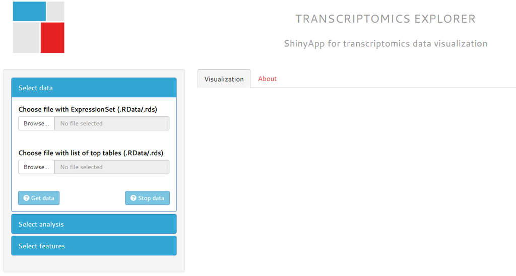

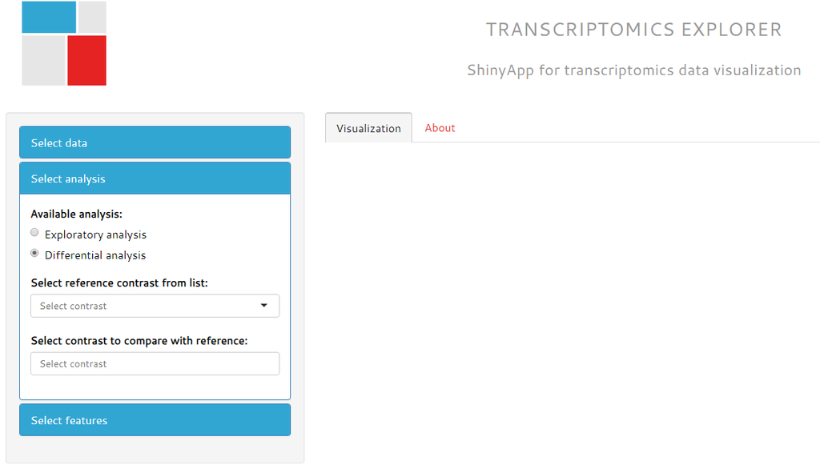

## transcriptomicsExplorer

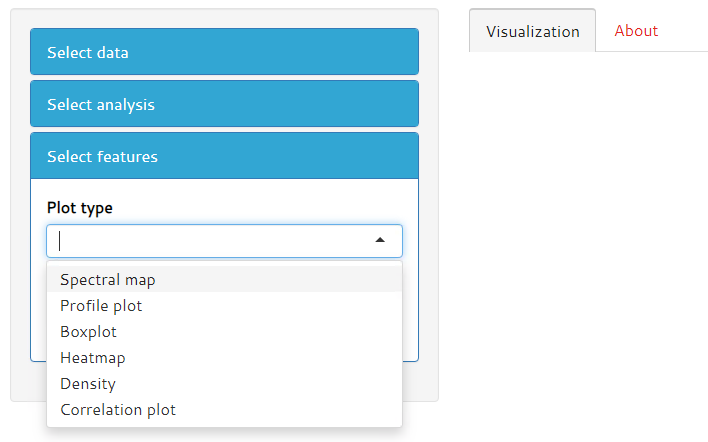

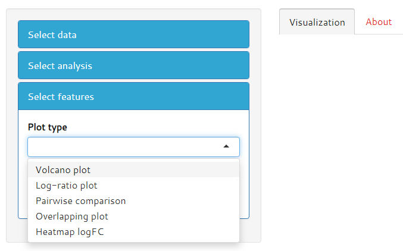

## transcriptomicsExplorer

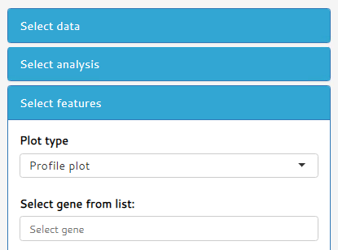

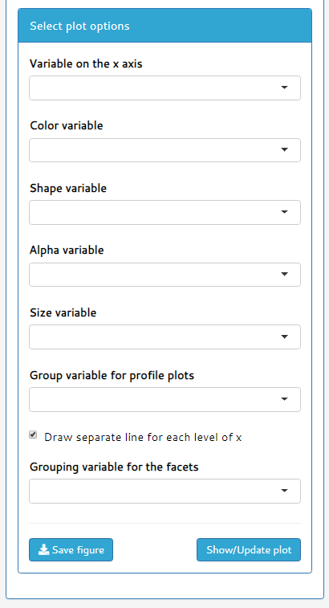

## transcriptomicsExplorer

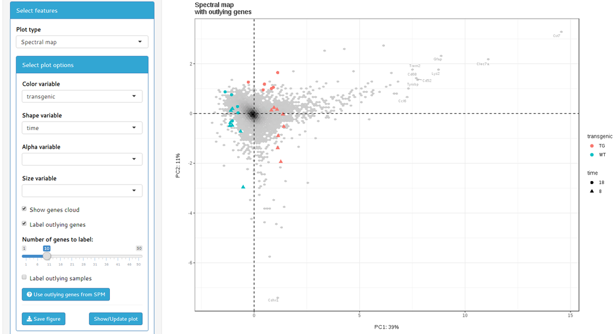

## Availability

esetVis, daVis and transcriptomicsExplorer will be:

- submitted to Bioconductor
- available at OpenAnalytics git repository (https://github.com/openanalytics)

## References

1. H. Wickham. ggplot2: Elegant Graphics for Data Analysis. Springer-Verlag New York, 2016.
2. Nils Gehlenborg (2019). UpSetR: A More Scalable Alternative to Venn and Euler Diagrams for Visualizing Intersecting Sets. R package version 1.4.0. https://CRAN.R-project.org/package=UpSetR
3. Li X (2019). ALL: A data package. R package version 1.28.0.
4. Barret Schloerke, Jason Crowley, Di Cook, Francois Briatte, Moritz Marbach, Edwin Thoen, Amos Elberg and Joseph Larmarange (2018). GGally: Extension to 'ggplot2'. R package version 1.4.0. https://CRAN.R-project.org/package=GGally
5. Orchestrating high-throughput genomic analysis with Bioconductor. W. Huber, V.J. Carey, R. Gentleman, …, M. Morgan Nature Methods, 2015:12, 115.
6. Winston Chang, Joe Cheng, JJ Allaire, Yihui Xie and Jonathan McPherson (2019). shiny: Web Application Framework for R. R package version 1.3.2. https://CRAN.R-project.org/package=shiny

## Thank you for your attention